# CW1 210123027

Lady Angel Mae Navarra

14/03/2024

## Coursework 1: US Unemployment 1948-1978

We are trying to project the monthly US unemployment from 1948-1978 and look at the impact of economic reasons and how it changes unemployment.

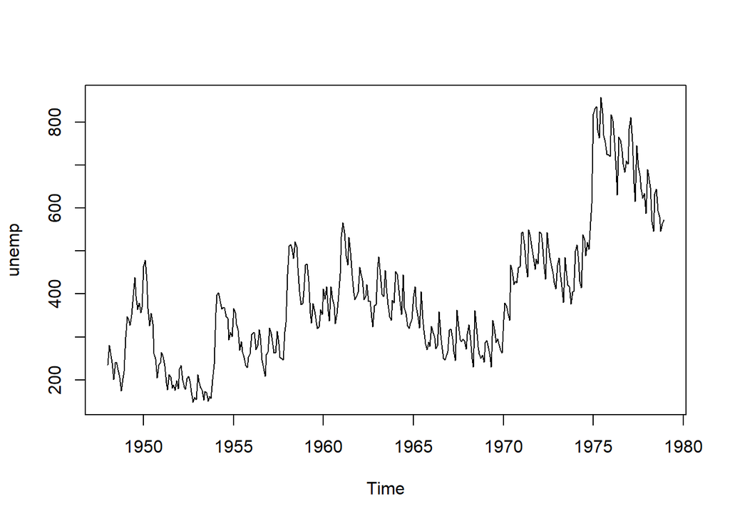

```r
library(astsa)
plot(unemp)
```

```r
summary(unemp)
```

```
##    Min. 1st Qu.  Median    Mean 3rd Qu.    Max.
##   148.0   279.8   366.1   393.0   467.6   856.9
```

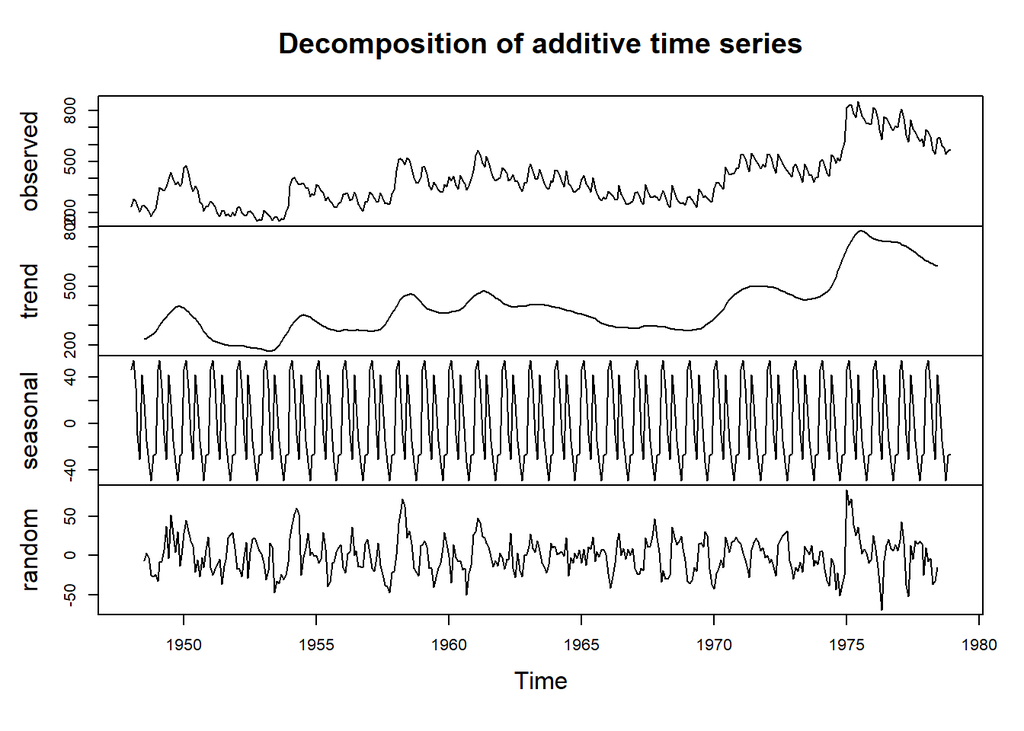

```r
d= decompose(unemp)
plot(d)
```

Our time series has formula of Xt=Mt+St+Yt

-Mt means that there is a trend evident where there is an increase from year 1968 to year 1975.

-St means seasonal effect an in out project there is a constant seasonality of unemployment throughout the period.

### Trend

```r
library (signal)
d$trend
```

```
##           Jan      Feb      Mar      Apr      May      Jun      Jul      Aug
## 1948       NA       NA       NA       NA       NA       NA 230.4167 235.8792
## 1949 285.7875 301.1833 314.9000 329.9625 344.8708 357.4625 370.5375 382.9125
## 1950 389.3500 379.2875 368.9208 356.9292 344.6500 334.2542 320.5875 302.8708
## 1951 233.0583 224.5125 218.6333 214.8625 212.0833 208.0042 203.8208 201.3667
## 1952 196.3375 196.8583 196.6667 194.8667 192.0750 189.3792 187.8083 185.7167
## 1953 175.9875 172.7333 170.5875 170.5167 172.6625 177.8375 187.2042 201.5708
## 1954 287.8708 304.2333 319.9500 333.1625 343.3917 350.6542 353.7917 352.5167
## 1955 320.0542 311.9250 303.4708 296.2208 291.1208 287.0083 282.7958 278.2958
## 1956 275.4917 276.5458 275.9875 274.9125 274.3708 274.8792 275.7083 276.2625
## 1957 270.9125 270.5708 271.7750 274.2917 278.0500 283.0500 291.0917 304.7958
## 1958 398.1458 416.2125 431.3625 443.1958 451.2917 457.1000 461.0583 460.2083
## 1959 407.9875 396.5167 387.6708 381.9125 379.1292 376.2292 371.6208 365.9083
## 1960 366.6875 369.3667 371.3833 373.1583 375.8125 381.1458 390.1667 402.6000
## 1961 455.8792 463.4042 469.4375 473.7917 475.0417 473.1458 468.3833 460.5208
```

[output cut: 49 more lines]

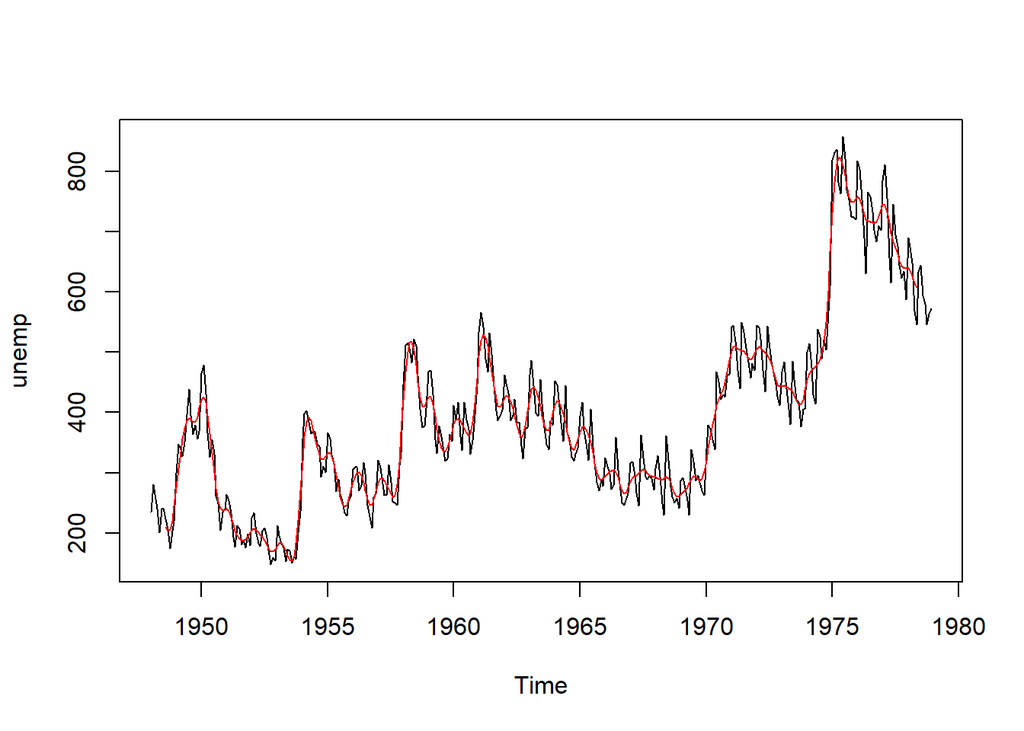

```r
plot (unemp)
lines ( stats :: filter (unemp, spencerFilter ()), type ="l", col="red")
```

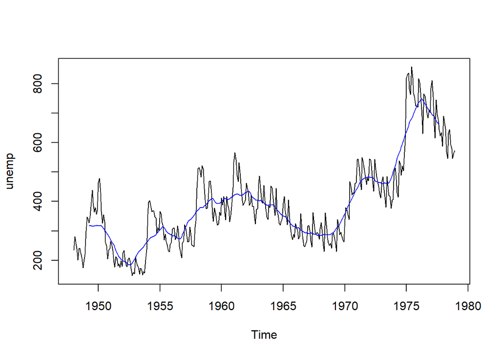

```r
q = 15
a = rep (1/(2*q+1) , 2*q+1)
m=stats :: filter (unemp , a )
plot(unemp)
lines (m , type ="l", col=" blue ")
```

### Seasonality

```r
d$seasonal
```

```
##             Jan        Feb        Mar        Apr        May        Jun
## 1948  46.751157  54.385602  30.880463  -9.577454 -30.505926  42.342407
## 1949  46.751157  54.385602  30.880463  -9.577454 -30.505926  42.342407
## 1950  46.751157  54.385602  30.880463  -9.577454 -30.505926  42.342407
## 1951  46.751157  54.385602  30.880463  -9.577454 -30.505926  42.342407
## 1952  46.751157  54.385602  30.880463  -9.577454 -30.505926  42.342407
## 1953  46.751157  54.385602  30.880463  -9.577454 -30.505926  42.342407
## 1954  46.751157  54.385602  30.880463  -9.577454 -30.505926  42.342407
## 1955  46.751157  54.385602  30.880463  -9.577454 -30.505926  42.342407
## 1956  46.751157  54.385602  30.880463  -9.577454 -30.505926  42.342407
## 1957  46.751157  54.385602  30.880463  -9.577454 -30.505926  42.342407
## 1958  46.751157  54.385602  30.880463  -9.577454 -30.505926  42.342407
## 1959  46.751157  54.385602  30.880463  -9.577454 -30.505926  42.342407
## 1960  46.751157  54.385602  30.880463  -9.577454 -30.505926  42.342407
## 1961  46.751157  54.385602  30.880463  -9.577454 -30.505926  42.342407
```

[output cut: 49 more lines]

There is a seasonality in our time series where based from the data during Christmas season, more people are getting temporary job and then after holidays,unemployment increases. Every January, unmeployment increases 46.751157.

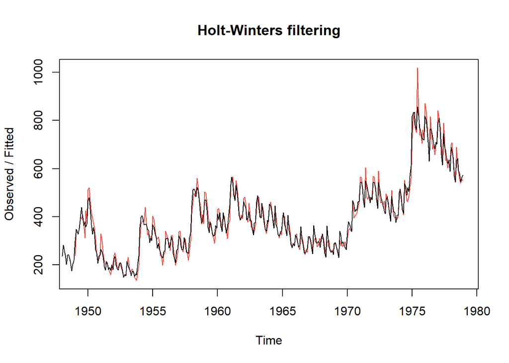

```r
s=HoltWinters(unemp, seasonal = "multiplicative")
plot(s)
```

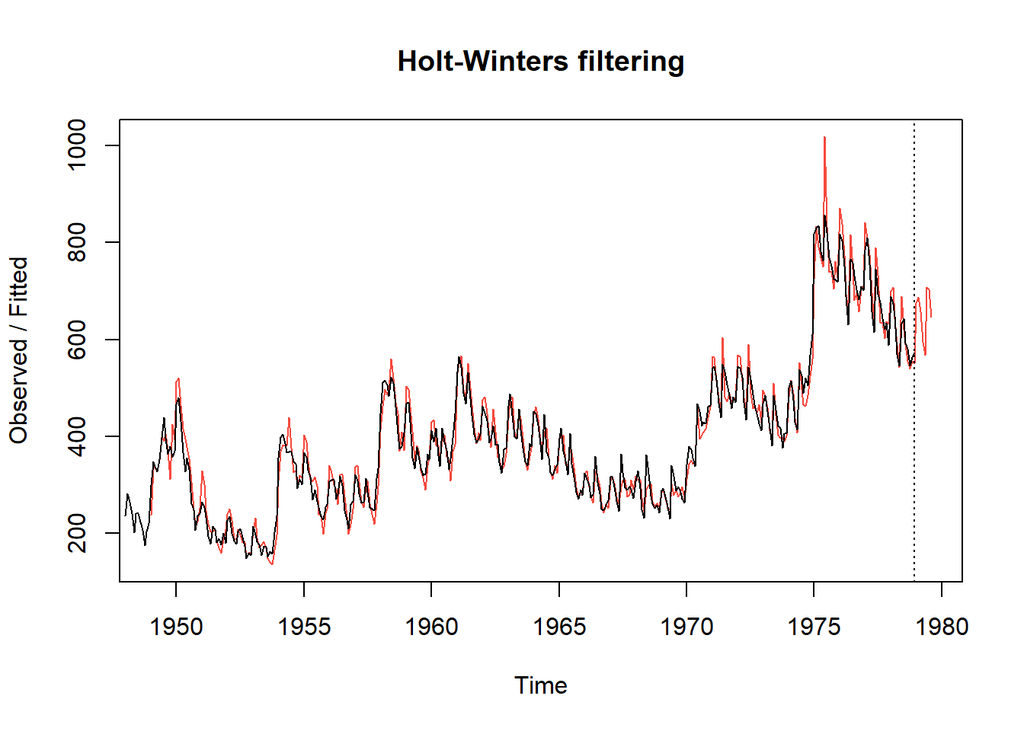

```r
p= predict(s,8)
plot(s,p)
library(mosaic)
```

```r
msummary(unemp)
```

```
##    Min. 1st Qu.  Median    Mean 3rd Qu.    Max.
##   148.0   279.8   366.1   393.0   467.6   856.9
```

For further Visualisation of unemployment by the end of December:

```r
library(dygraphs)
dygraph(unemp, main = "US Unemployment") %>%
  dyRangeSelector(dateWindow = c("1967-12-30", "1973-12-30"))
```

[interactive chart not shown]

We can see that unemployment increases by the end of December 1969 from 262.7 to 340.6 which further proves seasonal unemployment.

### Forecasting

An alternative forecasting system that we are going to use is prophet where it forecast trend and seasonality.

```r
library(zoo)
unemp.df= data.frame(ds=zoo:: as.yearmon(time(unemp)),y=unemp)
library(prophet)
m = prophet::prophet(unemp.df) # We will fit the model.
```

```
## Disabling weekly seasonality. Run prophet with weekly.seasonality=TRUE to override this.
```

```
## Disabling daily seasonality. Run prophet with daily.seasonality=TRUE to override this.
```

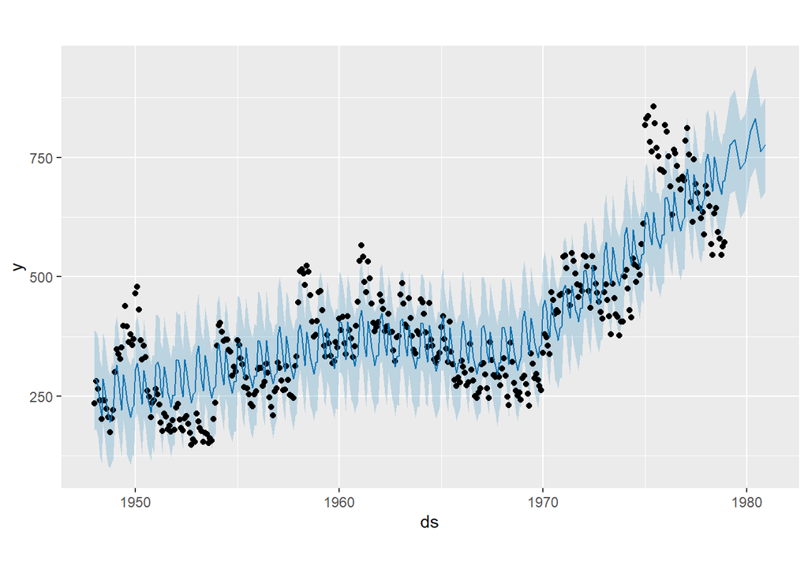

```r
f = prophet::make_future_dataframe(m, periods=8, freq="quarter")
p = predict(m, f)
plot(m,p)
```

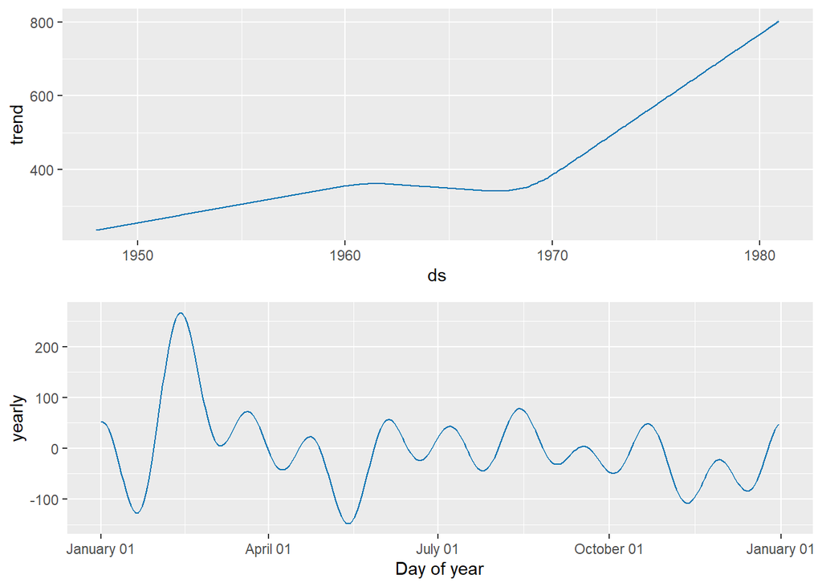

```r
prophet_plot_components(m,p)
```

In here, we can see that unemployment will continue to increase throughout the years by looking at the trend and there will be seasonal employment that will occur where people will get jobs during December that is why unemployment decreases and unemployment will then increase every January.

### Heteroscedasticity

We are going to use Breusch-Pagan test to test if our time series is heteroskedastic (variability in errors is not constant). By running the test we have assumed that our H0: there is constant variance or homoscedasticity in residual. If p> 0.05 then accept H0.

```r
library(lmtest)
data(unemp.df)
unemp_numeric <- data.frame(ds = as.numeric(unemp.df$ds), y = unemp.df$y)
model= lm(ds~y,data=unemp_numeric)
bptest(model)
```

```
##
##  studentized Breusch-Pagan test
##
## data:  model
## BP = 3.5776, df = 1, p-value = 0.05857
```

We have found that P value =0.05857 which is greater than 0.05 meaning that there is a constant variance. This suggests that our time series is not heteroskedastic thus it is not necessary to use Box-Cox or log transformation.